# K Means Clustering Project

Usually when dealing with an unsupervised learning problem, its difficult to get a good measure of how well the model performed. For this project, we will use data from the UCI archive based off of red and white wines (this is a very commonly used data set in ML).

We will then add a label to the a combined data set, we’ll bring this label back later to see how well we can cluster the wine into groups.

Use read.csv to open both data sets and set them as df1 and df2. Pay attention to what the separator (sep) is.

# imports and get data

```r
library(readr)
library(ggplot2)
library(cluster)
library(dplyr)
df1 <- read.csv('Training Exercises/Machine Learning Projects/CSV files for ML Projects/winequality-red.csv', sep = ";")

df2 <- read.csv('Training Exercises/Machine Learning Projects/CSV files for ML Projects/winequality-white.csv', sep = ";")
```

## Now add a label column to both df1 and df2 indicating a label ‘red’ or ‘white’.

```r
df1$Label <- "Red"
df2$Label <- "White"
```

## inspect the data

```r
head(df1)
```

|  | fixed.acidity | volatile.acidity | citric.acid | residual.sugar | chlorides | free.sulfur.dioxide | total.sulfur.dioxide | density | pH | sulphates | alcohol | quality | Label |
| --- | --- | --- | --- | --- | --- | --- | --- | --- | --- | --- | --- | --- | --- |
| 1 | 7.4 | 0.70 | 0.00 | 1.9 | 0.076 | 11 | 34 | 0.9978 | 3.51 | 0.56 | 9.4 | 5 | Red |
| 2 | 7.8 | 0.88 | 0.00 | 2.6 | 0.098 | 25 | 67 | 0.9968 | 3.20 | 0.68 | 9.8 | 5 | Red |
| 3 | 7.8 | 0.76 | 0.04 | 2.3 | 0.092 | 15 | 54 | 0.9970 | 3.26 | 0.65 | 9.8 | 5 | Red |
| 4 | 11.2 | 0.28 | 0.56 | 1.9 | 0.075 | 17 | 60 | 0.9980 | 3.16 | 0.58 | 9.8 | 6 | Red |
| 5 | 7.4 | 0.70 | 0.00 | 1.9 | 0.076 | 11 | 34 | 0.9978 | 3.51 | 0.56 | 9.4 | 5 | Red |
| 6 | 7.4 | 0.66 | 0.00 | 1.8 | 0.075 | 13 | 40 | 0.9978 | 3.51 | 0.56 | 9.4 | 5 | Red |

```r
head(df2)
```

|  | fixed.acidity | volatile.acidity | citric.acid | residual.sugar | chlorides | free.sulfur.dioxide | total.sulfur.dioxide | density | pH | sulphates | alcohol | quality | Label |
| --- | --- | --- | --- | --- | --- | --- | --- | --- | --- | --- | --- | --- | --- |
| 1 | 7.0 | 0.27 | 0.36 | 20.7 | 0.045 | 45 | 170 | 1.0010 | 3.00 | 0.45 | 8.8 | 6 | White |
| 2 | 6.3 | 0.30 | 0.34 | 1.6 | 0.049 | 14 | 132 | 0.9940 | 3.30 | 0.49 | 9.5 | 6 | White |
| 3 | 8.1 | 0.28 | 0.40 | 6.9 | 0.050 | 30 | 97 | 0.9951 | 3.26 | 0.44 | 10.1 | 6 | White |
| 4 | 7.2 | 0.23 | 0.32 | 8.5 | 0.058 | 47 | 186 | 0.9956 | 3.19 | 0.40 | 9.9 | 6 | White |
| 5 | 7.2 | 0.23 | 0.32 | 8.5 | 0.058 | 47 | 186 | 0.9956 | 3.19 | 0.40 | 9.9 | 6 | White |
| 6 | 8.1 | 0.28 | 0.40 | 6.9 | 0.050 | 30 | 97 | 0.9951 | 3.26 | 0.44 | 10.1 | 6 | White |

## Combine df1 and df2 into a single data frame called wine.

```r
wine <- df1 %>% full_join(df2)
head(wine)
```

|  | fixed.acidity | volatile.acidity | citric.acid | residual.sugar | chlorides | free.sulfur.dioxide | total.sulfur.dioxide | density | pH | sulphates | alcohol | quality | Label |
| --- | --- | --- | --- | --- | --- | --- | --- | --- | --- | --- | --- | --- | --- |
| 1 | 7.4 | 0.70 | 0.00 | 1.9 | 0.076 | 11 | 34 | 0.9978 | 3.51 | 0.56 | 9.4 | 5 | Red |
| 2 | 7.8 | 0.88 | 0.00 | 2.6 | 0.098 | 25 | 67 | 0.9968 | 3.20 | 0.68 | 9.8 | 5 | Red |
| 3 | 7.8 | 0.76 | 0.04 | 2.3 | 0.092 | 15 | 54 | 0.9970 | 3.26 | 0.65 | 9.8 | 5 | Red |
| 4 | 11.2 | 0.28 | 0.56 | 1.9 | 0.075 | 17 | 60 | 0.9980 | 3.16 | 0.58 | 9.8 | 6 | Red |
| 5 | 7.4 | 0.70 | 0.00 | 1.9 | 0.076 | 11 | 34 | 0.9978 | 3.51 | 0.56 | 9.4 | 5 | Red |
| 6 | 7.4 | 0.66 | 0.00 | 1.8 | 0.075 | 13 | 40 | 0.9978 | 3.51 | 0.56 | 9.4 | 5 | Red |

```r
tail(wine)
```

|  | fixed.acidity | volatile.acidity | citric.acid | residual.sugar | chlorides | free.sulfur.dioxide | total.sulfur.dioxide | density | pH | sulphates | alcohol | quality | Label |
| --- | --- | --- | --- | --- | --- | --- | --- | --- | --- | --- | --- | --- | --- |
| 6492 | 6.5 | 0.23 | 0.38 | 1.3 | 0.032 | 29 | 112 | 0.99298 | 3.29 | 0.54 | 9.7 | 5 | White |
| 6493 | 6.2 | 0.21 | 0.29 | 1.6 | 0.039 | 24 | 92 | 0.99114 | 3.27 | 0.50 | 11.2 | 6 | White |
| 6494 | 6.6 | 0.32 | 0.36 | 8.0 | 0.047 | 57 | 168 | 0.99490 | 3.15 | 0.46 | 9.6 | 5 | White |
| 6495 | 6.5 | 0.24 | 0.19 | 1.2 | 0.041 | 30 | 111 | 0.99254 | 2.99 | 0.46 | 9.4 | 6 | White |
| 6496 | 5.5 | 0.29 | 0.30 | 1.1 | 0.022 | 20 | 110 | 0.98869 | 3.34 | 0.38 | 12.8 | 7 | White |
| 6497 | 6.0 | 0.21 | 0.38 | 0.8 | 0.020 | 22 | 98 | 0.98941 | 3.26 | 0.32 | 11.8 | 6 | White |

```r
str(wine)
```

```
'data.frame':   6497 obs. of  13 variables:
 $ fixed.acidity       : num  7.4 7.8 7.8 11.2 7.4 7.4 7.9 7.3 7.8 7.5 ...
 $ volatile.acidity    : num  0.7 0.88 0.76 0.28 0.7 0.66 0.6 0.65 0.58 0.5 ...
 $ citric.acid         : num  0 0 0.04 0.56 0 0 0.06 0 0.02 0.36 ...
 $ residual.sugar      : num  1.9 2.6 2.3 1.9 1.9 1.8 1.6 1.2 2 6.1 ...
 $ chlorides           : num  0.076 0.098 0.092 0.075 0.076 0.075 0.069 0.065 0.073 0.071 ...
 $ free.sulfur.dioxide : num  11 25 15 17 11 13 15 15 9 17 ...
 $ total.sulfur.dioxide: num  34 67 54 60 34 40 59 21 18 102 ...
 $ density             : num  0.998 0.997 0.997 0.998 0.998 ...
 $ pH                  : num  3.51 3.2 3.26 3.16 3.51 3.51 3.3 3.39 3.36 3.35 ...
 $ sulphates           : num  0.56 0.68 0.65 0.58 0.56 0.56 0.46 0.47 0.57 0.8 ...
 $ alcohol             : num  9.4 9.8 9.8 9.8 9.4 9.4 9.4 10 9.5 10.5 ...
 $ quality             : int  5 5 5 6 5 5 5 7 7 5 ...
 $ Label               : chr  "Red" "Red" "Red" "Red" ...
```

```r
summary(wine)
```

```
 fixed.acidity    volatile.acidity  citric.acid     residual.sugar     chlorides
 Min.   : 3.800   Min.   :0.0800   Min.   :0.0000   Min.   : 0.600   Min.   :0.00900
 1st Qu.: 6.400   1st Qu.:0.2300   1st Qu.:0.2500   1st Qu.: 1.800   1st Qu.:0.03800
 Median : 7.000   Median :0.2900   Median :0.3100   Median : 3.000   Median :0.04700
 Mean   : 7.215   Mean   :0.3397   Mean   :0.3186   Mean   : 5.443   Mean   :0.05603
 3rd Qu.: 7.700   3rd Qu.:0.4000   3rd Qu.:0.3900   3rd Qu.: 8.100   3rd Qu.:0.06500
 Max.   :15.900   Max.   :1.5800   Max.   :1.6600   Max.   :65.800   Max.   :0.61100
 free.sulfur.dioxide total.sulfur.dioxide    density             pH          sulphates
 Min.   :  1.00      Min.   :  6.0        Min.   :0.9871   Min.   :2.720   Min.   :0.2200
 1st Qu.: 17.00      1st Qu.: 77.0        1st Qu.:0.9923   1st Qu.:3.110   1st Qu.:0.4300
 Median : 29.00      Median :118.0        Median :0.9949   Median :3.210   Median :0.5100
 Mean   : 30.53      Mean   :115.7        Mean   :0.9947   Mean   :3.219   Mean   :0.5313
 3rd Qu.: 41.00      3rd Qu.:156.0        3rd Qu.:0.9970   3rd Qu.:3.320   3rd Qu.:0.6000
 Max.   :289.00      Max.   :440.0        Max.   :1.0390   Max.   :4.010   Max.   :2.0000
    alcohol         quality         Label
 Min.   : 8.00   Min.   :3.000   Length:6497
 1st Qu.: 9.50   1st Qu.:5.000   Class :character
 Median :10.30   Median :6.000   Mode  :character
 Mean   :10.49   Mean   :5.818
 3rd Qu.:11.30   3rd Qu.:6.000
 Max.   :14.90   Max.   :9.000
```

# EDA

## Create a Histogram of residual sugar from the wine data. Color by red and white wines.

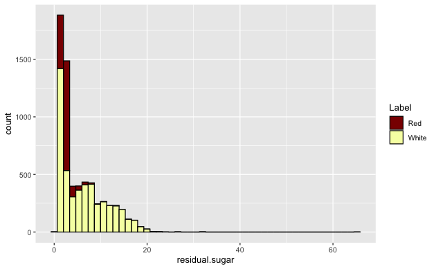

```r
ggplot(wine, aes(x=residual.sugar)) + geom_histogram(aes(fill=Label), col='black', bins = 50) + scale_fill_manual(values = c('#8B0000','#F6FEB1'))
```

## Create a Histogram of citric.acid from the wine data. Color by red and white wines.

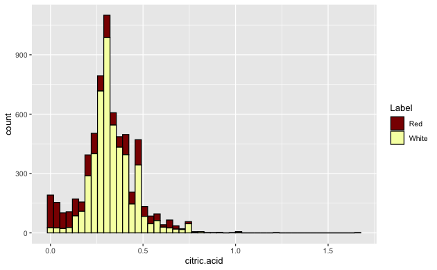

```r
ggplot(wine, aes(x=citric.acid)) + geom_histogram(aes(fill=Label), col='black', bins = 50) + scale_fill_manual(values = c('#8B0000','#F6FEB1'))
```

## Create a Histogram of alcohol from the wine data. Color by red and white wines.

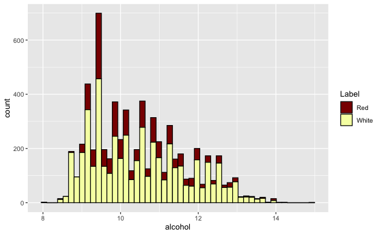

```r
ggplot(wine, aes(x=alcohol)) + geom_histogram(aes(fill=Label), col='black', bins = 50) + scale_fill_manual(values = c('#8B0000','#F6FEB1'))
```

## Create a scatterplot of residual.sugar versus citric.acid, color by red and white wine.

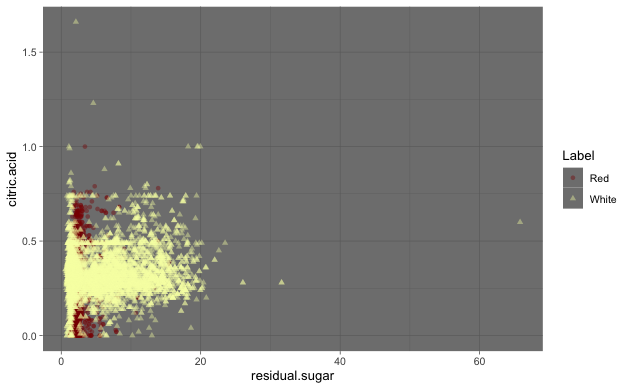

```r
ggplot(wine, aes(x=residual.sugar, y=citric.acid)) + geom_point(aes(col=Label, shape=Label), alpha=0.4) + scale_color_manual(values = c('#8B0000','#F6FEB1')) + theme_dark()
```

## Create a scatterplot of volatile.acidity versus residual.sugar, color by red and white wine.

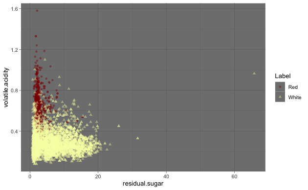

```r
ggplot(wine, aes(x=residual.sugar, y=volatile.acidity)) + geom_point(aes(col=Label, shape=Label), alpha=0.4) + scale_color_manual(values = c('#8B0000','#F6FEB1')) + theme_dark()
```

# Clustering

## Grab the wine data without the label and call it clus.data

```r
# stop at the 12th column because we want to get rid of Label.
clus.data <- wine[,1:12]
head(clus.data)
```

|  | fixed.acidity | volatile.acidity | citric.acid | residual.sugar | chlorides | free.sulfur.dioxide | total.sulfur.dioxide | density | pH | sulphates | alcohol | quality |
| --- | --- | --- | --- | --- | --- | --- | --- | --- | --- | --- | --- | --- |
| 1 | 7.4 | 0.70 | 0.00 | 1.9 | 0.076 | 11 | 34 | 0.9978 | 3.51 | 0.56 | 9.4 | 5 |
| 2 | 7.8 | 0.88 | 0.00 | 2.6 | 0.098 | 25 | 67 | 0.9968 | 3.20 | 0.68 | 9.8 | 5 |
| 3 | 7.8 | 0.76 | 0.04 | 2.3 | 0.092 | 15 | 54 | 0.9970 | 3.26 | 0.65 | 9.8 | 5 |
| 4 | 11.2 | 0.28 | 0.56 | 1.9 | 0.075 | 17 | 60 | 0.9980 | 3.16 | 0.58 | 9.8 | 6 |
| 5 | 7.4 | 0.70 | 0.00 | 1.9 | 0.076 | 11 | 34 | 0.9978 | 3.51 | 0.56 | 9.4 | 5 |
| 6 | 7.4 | 0.66 | 0.00 | 1.8 | 0.075 | 13 | 40 | 0.9978 | 3.51 | 0.56 | 9.4 | 5 |

## calculate the best K number using elbow method

This isn’t necessary (we only have two clusters), but I just found out how to do it so I’ll leave the code in the project.

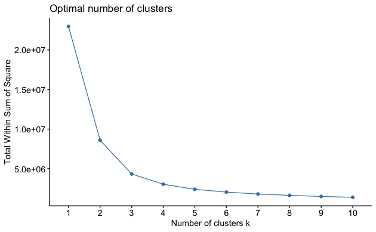

```r
library(factoextra)
fviz_nbclust(clus.data, kmeans, method= "wss")
```

```r
# + geom_vline(xintercept = 3, linetype = 2)
```

## Call the kmeans function on clus.data and assign the results to wine.cluster.

```r
set.seed(101)

# arguments for kmeans: dataset, K, number of iterations
wine.cluster <- kmeans(clus.data, 2, nstart = 20)

wine.cluster
```

[output not shown]

## Print out the wine.cluster Cluster Means and explore the information.

```r
wine.cluster$centers
```

```
  fixed.acidity volatile.acidity citric.acid residual.sugar  chlorides free.sulfur.dioxide
1      7.623219        0.4086378   0.2908725       3.076425 0.06580983            18.39868
2      6.904812        0.2871659   0.3397642       7.244809 0.04859257            39.75590
  total.sulfur.dioxide   density       pH sulphates  alcohol  quality
1             63.26318 0.9945736 3.254882 0.5724145 10.79722 5.810541
2            155.69246 0.9947903 3.190808 0.4999485 10.25932 5.824343
```

# Evaluating the Clusters

You usually won’t have the luxury of labeled data with KMeans, but let’s go ahead and see how we did!

## Use the table() function to compare your cluster results to the real results. Which is easier to correctly group, red or white wines?

```r
table(wine$Label, wine.cluster$cluster)
```

```
           1    2
  Red   1514   85
  White 1294 3604
```

Red is easier to cluster.